# Olympic Athletes with GDP and Population

2025-04-14

# Olympic Athletes with GDP and Population

**Students: Rami BELGUITH , ……**

## 1. Introduction

This project explores the relationship between Olympic athletic success and national wealth/population statistics using historical Olympic Games data, along with World Bank data on GDP per capita and total population.

### Context & Dataset Description

- **Olympic Dataset**: `athlete_events.csv` from Kaggle contains data on all athletes who participated in the Olympic Games from 1896 to 2016.
- **GDP & Population**: Extracted from the World Bank, representing GDP per capita and population for most countries between 1960 and 2020.

### How the Dataset Has Been Obtained?

- The Olympic data was downloaded from Kaggle.
- GDP and population datasets were downloaded from the World Bank’s data portal.

### Description of the Question

We aim to study: - Whether wealthier countries (by GDP per capita) win more Olympic medals. - How population size affects medal counts per capita.

## 2. Methodology

### Data Clean-up Procedures

- Dropped irrelevant columns from the Olympic dataset (`Season`, `Games`).
- Renamed columns for consistency.
- Converted GDP and population data from wide to long format.
- Filtered out invalid countries (e.g., mixed teams, regions).
- Merged datasets using country name and year.

### Scientific Workflow

1. Clean datasets.
2. Convert and align formats.
3. Merge on common keys.
4. Analyze medal counts vs GDP/population.
5. Visualize results.

### Data Representation Choices

- Used log-log plots to handle skewed data distributions.
- Boxplots to show relative medals per million by population group.
- Used color scales and labels to highlight outliers.

## 3. Data Preparation

We first start by reading the input data

```r
athletes <- read.csv("C:/Users/errmi/Desktop/MPSL/athlete_events.csv")


gdp <- read.csv("C:/Users/errmi/Desktop/MPSL/API_NY.GDP.PCAP.CD_DS2_en_csv_v2_26433.csv", skip = 4)


population <- read.csv("C:/Users/errmi/Desktop/MPSL/API_SP.POP.TOTL_DS2_en_csv_v2_26346.csv", skip = 4)
```

we will now get rid of redundant columns in the olympics dataset ( by removing the columns season and games)

```r
athletes_clean <- athletes[, !(names(athletes) %in% c("Season", "Games"))]

head(athletes_clean)
```

```
##   ID                     Name Sex Age Height Weight           Team NOC Year
## 1  1                A Dijiang   M  24    180     80          China CHN 1992
## 2  2                 A Lamusi   M  23    170     60          China CHN 2012
## 3  3      Gunnar Nielsen Aaby   M  24     NA     NA        Denmark DEN 1920
## 4  4     Edgar Lindenau Aabye   M  34     NA     NA Denmark/Sweden DEN 1900
## 5  5 Christine Jacoba Aaftink   F  21    185     82    Netherlands NED 1988
## 6  5 Christine Jacoba Aaftink   F  21    185     82    Netherlands NED 1988
##        City         Sport                              Event Medal
## 1 Barcelona    Basketball        Basketball Men's Basketball  <NA>
## 2    London          Judo       Judo Men's Extra-Lightweight  <NA>
## 3 Antwerpen      Football            Football Men's Football  <NA>
## 4     Paris    Tug-Of-War        Tug-Of-War Men's Tug-Of-War  Gold
## 5   Calgary Speed Skating   Speed Skating Women's 500 metres  <NA>
## 6   Calgary Speed Skating Speed Skating Women's 1,000 metres  <NA>
```

then we change the format of the two datasets taken from world bank data to put them in long format instead of the original wide format

```r
library(tidyverse)
library(readr)

# GDP long format
gdp_long <- gdp %>%
  select(`Country.Name`, starts_with("X19"), starts_with("X20")) %>%
  pivot_longer(cols = starts_with("X"), names_to = "Year", values_to = "GDP") %>%
  mutate(Year = as.integer(sub("X", "", Year))) %>%
  rename(Country = `Country.Name`)

# Population long format
pop_long <- population %>%
  select(`Country.Name`, starts_with("X19"), starts_with("X20")) %>%
  pivot_longer(cols = starts_with("X"), names_to = "Year", values_to = "Population") %>%
  mutate(Year = as.integer(sub("X", "", Year))) %>%
  rename(Country = `Country.Name`)

# Preview
head(gdp_long)
```

```
## # A tibble: 6 × 3
##   Country  Year   GDP
##   <chr>   <int> <dbl>
## 1 Aruba    1960    NA
## 2 Aruba    1961    NA
## 3 Aruba    1962    NA
## 4 Aruba    1963    NA
## 5 Aruba    1964    NA
## 6 Aruba    1965    NA
```

```r
head(pop_long)
```

```
## # A tibble: 6 × 3
##   Country  Year Population
##   <chr>   <int>      <dbl>
## 1 Aruba    1960      54922
## 2 Aruba    1961      55578
## 3 Aruba    1962      56320
## 4 Aruba    1963      57002
## 5 Aruba    1964      57619
## 6 Aruba    1965      58190
```

## 4. Merging Datasets

after filtering the countries using a list from the gdp and populations datasets since the column team in athletes dataset sometimes has non country elements , we will then merge the three datasets left joining using the year and the country which corresponds to the column team in the athlets dataset

```r
# Get list of valid countries from GDP and Population datasets
valid_countries <- union(gdp_long$Country, pop_long$Country) %>% unique()

# Prepare and merge only valid countries
athletes_merged <- athletes_clean %>%
  rename(Country = Team) %>%
  filter(Country %in% valid_countries) %>%
  mutate(Year = as.integer(Year)) %>%
  left_join(gdp_long, by = c("Country", "Year")) %>%
  left_join(pop_long, by = c("Country", "Year"))

# Check result
head(athletes_merged)
```

```
##   ID                     Name Sex Age Height Weight     Country NOC Year
## 1  1                A Dijiang   M  24    180     80       China CHN 1992
## 2  2                 A Lamusi   M  23    170     60       China CHN 2012
## 3  3      Gunnar Nielsen Aaby   M  24     NA     NA     Denmark DEN 1920
## 4  5 Christine Jacoba Aaftink   F  21    185     82 Netherlands NED 1988
## 5  5 Christine Jacoba Aaftink   F  21    185     82 Netherlands NED 1988
## 6  5 Christine Jacoba Aaftink   F  25    185     82 Netherlands NED 1992
##          City         Sport                              Event Medal        GDP
## 1   Barcelona    Basketball        Basketball Men's Basketball  <NA>   366.4607
## 2      London          Judo       Judo Men's Extra-Lightweight  <NA>  6300.5822
## 3   Antwerpen      Football            Football Men's Football  <NA>         NA
## 4     Calgary Speed Skating   Speed Skating Women's 500 metres  <NA> 17770.6162
## 5     Calgary Speed Skating Speed Skating Women's 1,000 metres  <NA> 17770.6162
## 6 Albertville Speed Skating   Speed Skating Women's 500 metres  <NA> 23939.2173
##   Population
## 1 1164970000
## 2 1354190000
## 3         NA
## 4   14760094
## 5   14760094
## 6   15184166
```

after merging the data and in order to make the first graphs we ll have to filter everytime what s is not available such as the GDP and population

```r
# Total medals per country (across all years)
# Filter to real medals, deduplicate per medal event
medals_cleaned <- athletes_merged %>%
  filter(!is.na(Medal)) %>%
  distinct(Country, Year, Event, Medal, Sport)

# Join GDP & Population again
medals_summary <- medals_cleaned %>%
  left_join(gdp_long, by = c("Country", "Year")) %>%
  left_join(pop_long, by = c("Country", "Year")) %>%
  group_by(Country) %>%
  summarise(
    Total_Medals = n(),
    GDP = max(GDP, na.rm = TRUE),
    Population = max(Population, na.rm = TRUE),
    .groups = "drop"
  )
# Check result
head(medals_summary)
```

```
## # A tibble: 6 × 4
##   Country     Total_Medals    GDP Population
##   <chr>              <int>  <dbl>      <dbl>
## 1 Afghanistan            2   651.   30560034
## 2 Algeria               17  6034.   40850721
## 3 Argentina             72 12950.   43900313
## 4 Armenia               16  3778.    3278735
## 5 Australia            512 68073.   24190907
## 6 Austria              310 51581.    8736668
```

## 5. Analysis

### 5.1 GDP vs Total Medals

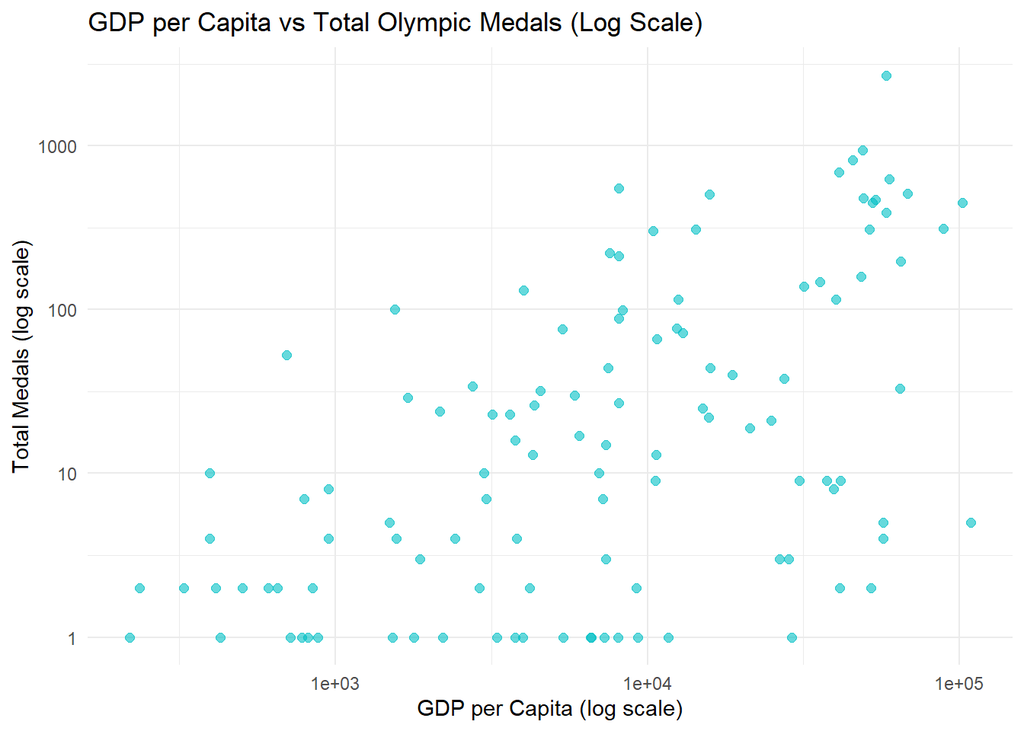

```r
library(dplyr)
library(ggplot2)

# Clean the data
medals_clean <- medals_summary %>%
  filter(
    !is.na(GDP),
    !is.na(Total_Medals)
  )


ggplot(medals_clean, aes(x = GDP, y = Total_Medals)) +
  geom_point(alpha = 0.6, color = "#00BFC4", size = 2) +
  scale_x_log10() +
  scale_y_log10() +
  labs(
    title = "GDP per Capita vs Total Olympic Medals (Log Scale)",
    x = "GDP per Capita (log scale)",
    y = "Total Medals (log scale)"
  ) +
  theme_minimal()
```

the relationship between GDP per capita and the total number of Olympic medals won by countries. Overall, there is a weak but noticeable positive trend, suggesting that countries with higher GDP per capita tend to win more medals. However, the correlation is not strong countries with modest GDP still achieve high medal counts, likely due to strong sports infrastructure or cultural emphasis on athletics. Conversely, many wealthy countries cluster with low to moderate medal counts. This implies that while economic wealth can support athletic success, it is not the only determining factor

### 5.2 Medals per Million by Population Group

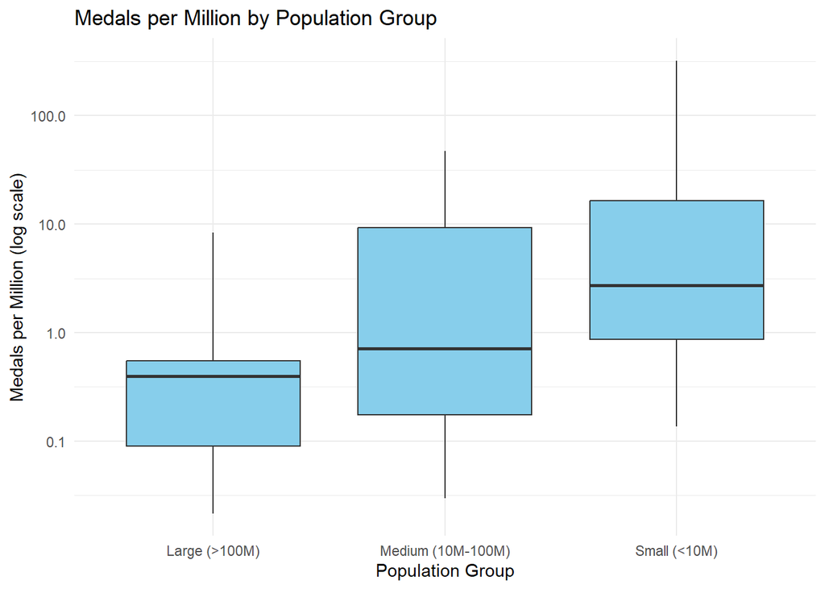

```r
library(ggplot2)
library(dplyr)

# Filter out countries with missing population
medals_summary_normalized <- medals_summary %>%
  filter(!is.na(Population), Population > 0) %>%
  mutate(
    Medals_per_Million = Total_Medals / (Population / 1e6),
    Pop_Group = case_when(
      Population < 1e7 ~ "Small (<10M)",
      Population < 1e8 ~ "Medium (10M-100M)",
      TRUE ~ "Large (>100M)"
    )
  )

ggplot(medals_summary_normalized, aes(x = Pop_Group, y = Medals_per_Million)) +
  geom_boxplot(fill = "skyblue") +
  scale_y_log10() +
  labs(
    title = "Medals per Million by Population Group",
    x = "Population Group",
    y = "Medals per Million (log scale)"
  ) +
  theme_minimal()
```

From the graph, we can observe that that smaller countries tend to win more medals per million people than larger ones. While large populations offer a bigger talent pool, they don’t guarantee Olympic success. Medium-sized and small countries often perform better relative to their population, likely due to stronger sports programs or focused investment.

### 5.3 Highlighting Top Countries

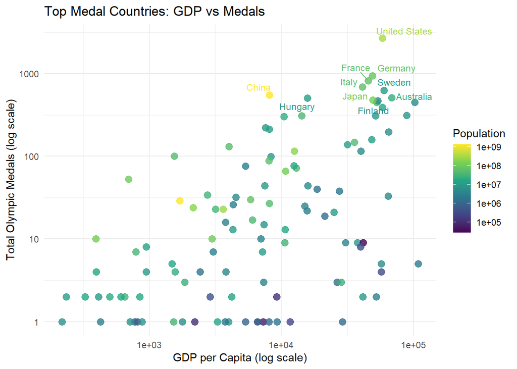

```r
library(ggplot2)
library(dplyr)

library(ggrepel)
medals_colored <- medals_summary_normalized %>%
  filter(!is.na(GDP), !is.na(Population), Total_Medals > 0)


top_medals <- medals_colored %>%
  arrange(desc(Total_Medals)) %>%
  slice_head(n = 10)

ggplot(medals_colored, aes(x = GDP, y = Total_Medals, color = Population)) +
  geom_point(alpha = 0.8, size = 3) +
  scale_x_log10() +
  scale_y_log10() +
  scale_color_viridis_c(trans = "log10") +
  geom_text_repel(data = top_medals, aes(label = Country), size = 3.2) +
  labs(
    title = "Top Medal Countries: GDP vs Medals",
    x = "GDP per Capita (log scale)",
    y = "Total Olympic Medals (log scale)",
    color = "Population"
  ) +
  theme_minimal()
```

we can conclude that countries with higher GDP per capita generally win more Olympic medals, especially those with moderate to large populations. While most high-population countries cluster at lower medal counts, a few exceptions—likely including China and the U.S.—stand out with both high population and high medal tallies. Overall, GDP per capita appears to be a stronger a stronger indicator of Olympic success than population alone.

## 6. Conclusion

There is a weak positive relationship between GDP per capita and Olympic medal counts, suggesting that economic strength helps but is not the sole predictor of success. Smaller and mid-sized countries often perform better per capita due to more focused programs.

This analysis highlights that wealth and population alone do not guarantee Olympic dominance — cultural, political, and structural factors also play key roles.

## 7. References

- Olympic Data: https://www.kaggle.com/datasets/heesoo37/120-years-of-olympic-history-athletes-and-results
- World Bank GDP/Population: https://data.worldbank.org